# PA1_template

Simon Baumgart

April 8, 2019

This RMarkdown document describes the analysis and returns the figures for the first assignment of the Coursera Course “Reproducible Research”.

# instructions for the assignment1

[the instructions on the coursera website](https://www.coursera.org/learn/reproducible-research/peer/gYyPt/course-project-1)  
[data used for this assignment](https://d396qusza40orc.cloudfront.net/repdata%2Fdata%2Factivity.zip)

Information about the data which contains collected data from various mobile devices tracking steps:  
“This device collects data at 5 minute intervals through out the day. The data consists of two months of data from an anonymous individual collected during the months of October and November, 2012 and include the number of steps taken in 5 minute intervals each day.”

1.) Code for reading in the dataset and/or processing the data

```r
activity <- read.csv("~/Data_Science/reproducible_reserch/assignment1/activity.csv")
activity$date <- as.Date(activity$date) # transform to dates
```

1.1) data exploration

```r
dim(activity)
```

```
## [1] 17568     3
```

```r
str(activity)
```

```
## 'data.frame':    17568 obs. of  3 variables:
##  $ steps   : int  NA NA NA NA NA NA NA NA NA NA ...
##  $ date    : Date, format: "2012-10-01" "2012-10-01" ...
##  $ interval: int  0 5 10 15 20 25 30 35 40 45 ...
```

```r
head(activity)
```

```
##   steps       date interval
## 1    NA 2012-10-01        0
## 2    NA 2012-10-01        5
## 3    NA 2012-10-01       10
## 4    NA 2012-10-01       15
## 5    NA 2012-10-01       20
## 6    NA 2012-10-01       25
```

```r
summary(activity)
```

```
##      steps             date               interval
##  Min.   :  0.00   Min.   :2012-10-01   Min.   :   0.0
##  1st Qu.:  0.00   1st Qu.:2012-10-16   1st Qu.: 588.8
##  Median :  0.00   Median :2012-10-31   Median :1177.5
##  Mean   : 37.38   Mean   :2012-10-31   Mean   :1177.5
##  3rd Qu.: 12.00   3rd Qu.:2012-11-15   3rd Qu.:1766.2
##  Max.   :806.00   Max.   :2012-11-30   Max.   :2355.0
##  NA's   :2304
```

```r
dim(activity[is.na(activity$steps),])
```

```
## [1] 2304    3
```

2.) Histogram of the total number of steps taken each day  
Note: we can ignore the missing values at first

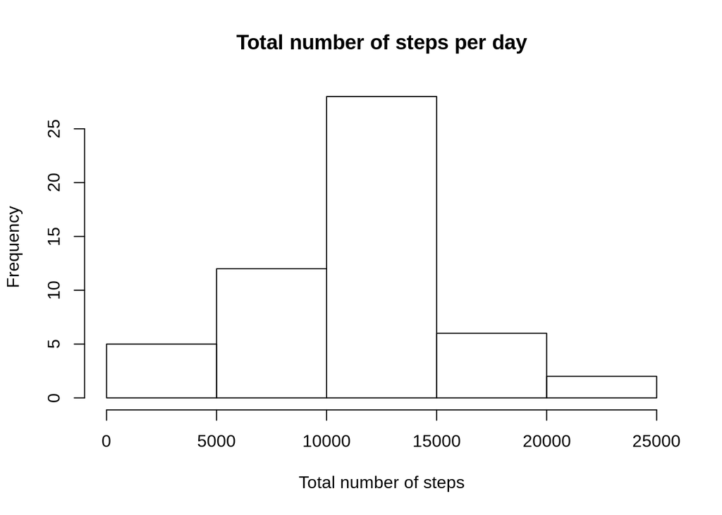

```r
activity_NArm <- activity[!is.na(activity$steps),] #remove NAs
stepsPerDay <- with(activity_NArm, tapply(steps, date, FUN=sum))
hist(stepsPerDay, main = "Total number of steps per day", xlab = "Total number of steps")
```

3. ) Mean and median number of steps taken each day

```r
summary(stepsPerDay)
```

```
##    Min. 1st Qu.  Median    Mean 3rd Qu.    Max.
##      41    8841   10765   10766   13294   21194
```

4.) Time series plot of the average number of steps taken

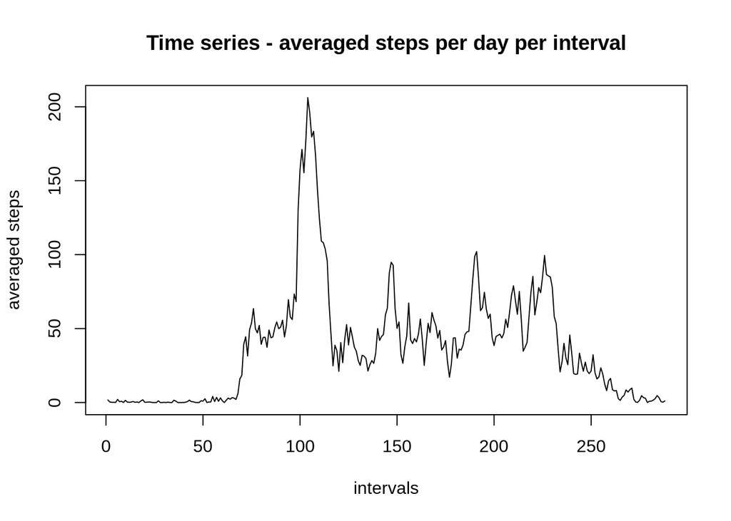

```r
r1<-with(activity_NArm, tapply(steps, activity_NArm$interval, mean, na.rm=TRUE))
plot(r1, type = "l", main = "Time series - averaged steps per day per interval", ylab  ="averaged steps", xlab ="intervals")
```

5.) The 5-minute interval that, on average, contains the maximum number of steps

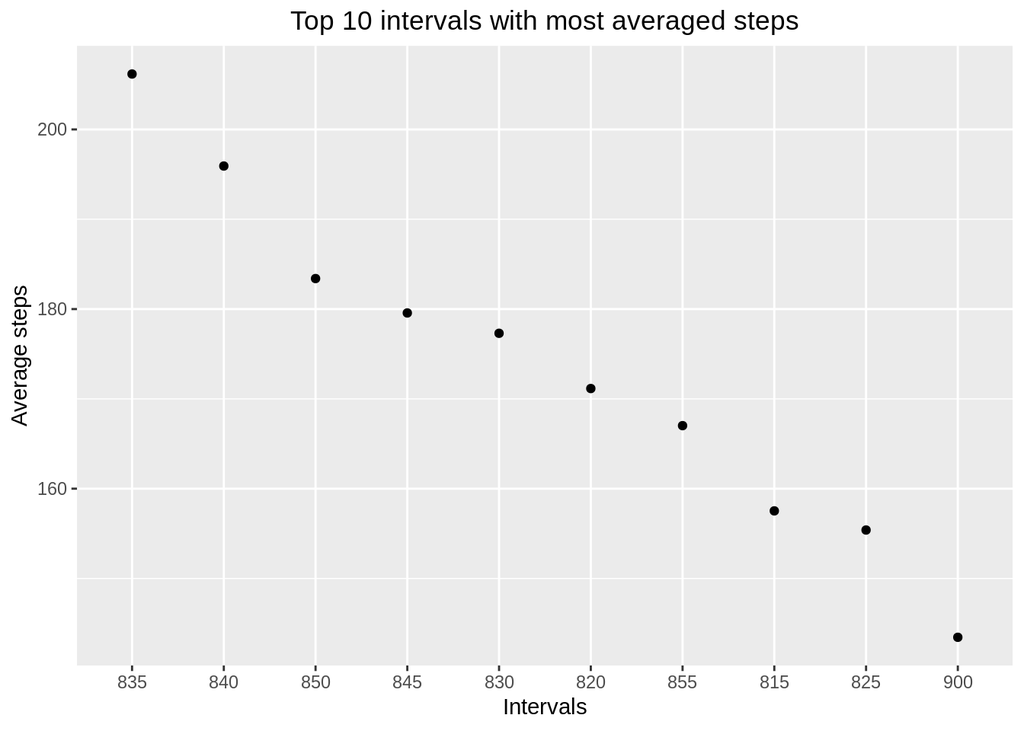

```r
library(data.table)
library(ggplot2)

activity_intervals <- activity_NArm[,c(1,3)] # subset data
activity_intervals$interval <- as.factor(activity_intervals$interval) # factor intervals for plotting
dF.activity_intervals <- as.data.frame(with(activity_intervals, tapply(steps, interval, mean))) # calculate the mean steps per interval over all days

dF.activity_intervals <- setDT(dF.activity_intervals, keep.rownames = TRUE) # transform dF for plotting
colnames(dF.activity_intervals) <- c("interval", "avSteps")
dF.activity_intervals <- dF.activity_intervals[order(dF.activity_intervals$avSteps, decreasing = T),][1:10,] # subset top 10 intervals regardinng number of steps
ggplot(data = dF.activity_intervals , aes(x = reorder(interval, -avSteps), y = avSteps )) + geom_point() + xlab("Intervals") + ylab("Average steps") + ggtitle("Top 10 intervals with most averaged steps") +
  theme(plot.title = element_text(hjust = 0.5))
```

```r
top1 <- dF.activity_intervals[1,]
```

Interval 835 with 206.1698113 steps has on average the highest step count of all intervals in this dataset.

6.) Code to describe and show a strategy for imputing missing data My strategy is to compute the mean value of stepts per interval for all days, excluding the NA values. This average per interval is then assigned to the corresponding interval for the missing data.  
For example if interval 5 has an average of 0.46 steps over all days, then the missing interval 5 at Day “2012-10-01” will be imputed with 0.46.

6.1) Code to describe and show a strategy for imputing missing data

```r
NADates <-unique(activity[is.na(activity$steps), "date"]) # identify the dates with NA

activity_intervals <- activity[,c(1,3)] # subset the data to interval and the step columns only
activity_intervals$interval <- as.factor(activity_intervals$interval) # factor the intervals to assign later an average to each interval
meanSteps <- with(activity_intervals, tapply(steps, interval, mean, na.rm = TRUE)) # calculate the mean for each interval
meanSteps <- as.data.frame(meanSteps)

activity[activity$date %in% NADates, "steps"] <- meanSteps$meanSteps # replace the missing values
```

7.) Histogram of the total number of steps taken each day after missing values are imputed

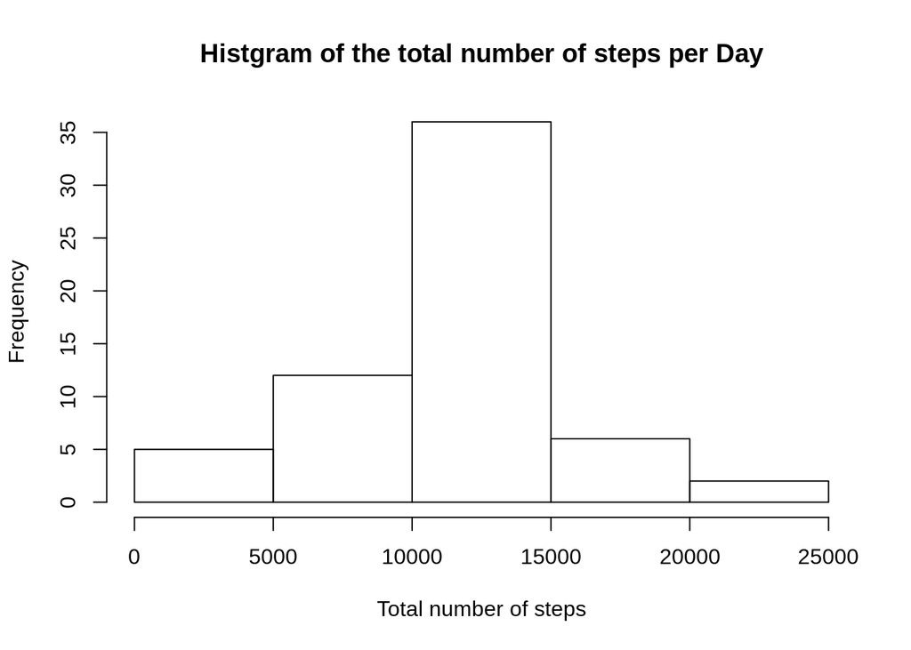

```r
stepsPerDay <- with(activity, tapply(steps, date, FUN=sum, na.rm = TRUE))
hist(stepsPerDay, main = "Histgram of the total number of steps per Day", xlab = "Total number of steps")
```

8.) Panel plot comparing the average number of steps taken per 5-minute interval across weekdays and weekends

```r
library(dplyr)
```

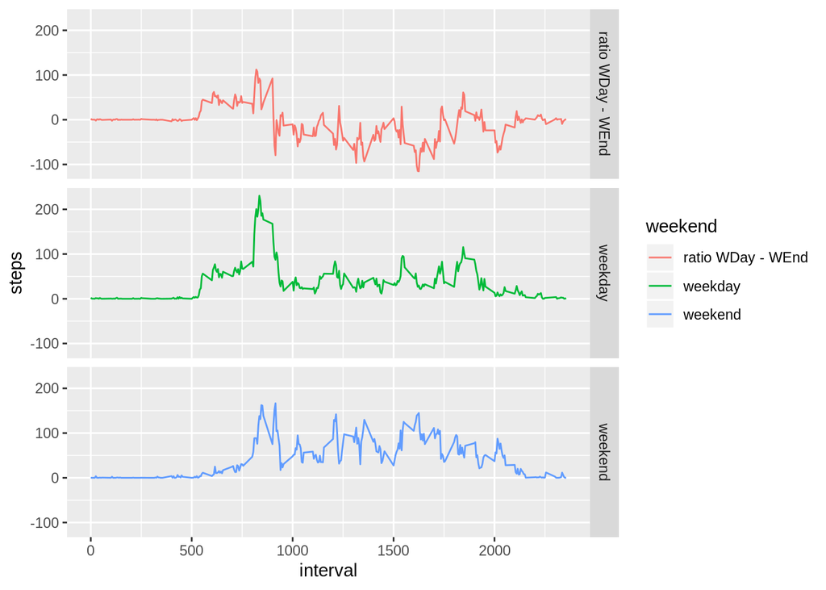

```r
library(chron)

#define weekends:
activity$weekdays <- weekdays(as.POSIXct(activity$date), abbreviate = F) # add a column with the day names
activity$weekdays <- as.factor(activity$weekdays) # weekdays to factors
activity$weekend <- is.weekend(activity$date) # define weekends

activity[which(activity$weekend == "FALSE"), "weekend"] <- "weekday" # add labels
activity[which(activity$weekend == "TRUE"), "weekend"] <- "weekend" # add labels

# calculate the mean steps per interval grouped on weekend and interval
daysCompare <- activity %>%
    group_by(weekend, interval) %>%
    summarize(steps=mean(steps))

# create a table with the ratio of the steps taken on weekdays and weekends
daysCompareRatio <- data.table()
daysCompareRatio <- data.table(daysCompare[which(daysCompare$weekend == "weekday"),"steps"] - daysCompare[which(daysCompare$weekend == "weekend"),"steps"])
daysCompareRatio$interval <- daysCompare[1:288, "interval"]
daysCompareRatio$weekend <- "ratio WDay - WEnd"

# plot the data
dTPlot <- (merge.data.frame(daysCompareRatio, daysCompare, all = TRUE))

ggplot(data = dTPlot, aes(x=interval, y=steps, col = weekend)) +facet_grid(weekend~.)  + geom_line()
```